# ISYE 6402 Project Multivariate Analysis

**Date:** The date during which each data point was recorded

**BTC:** Closing stock price for Bitcoin

**BNB:** Closing stock price for Binance Coin

**ETH:** Closing stock price for Ether

**XRP:** Closing stock price for XRP

**DOGE:** Closing stock price for Dogecoin

```r
library(zoo)
library(lubridate)
library(mgcv)
library(TSA)
library(xts)
library(vars)
library(rugarch)
library(aod)
```

# Instructions on reading the data

To read the data in `R`, save the file in your working directory (make sure you have changed the directory if different from the R working directory) and read the data using the `R` function `read.csv()`

```r
#Read in data
#create data frame with 0 rows and 3 columns
data <- data.frame(matrix(ncol = 6, nrow = 1240))
#provide column names
colnames(data) <- c('Date','BTC', 'BNB', 'ETH','XRP','DOGE')
data[,1] <-read.csv("BTC.csv", head = TRUE)$Date
data[,2] <-read.csv("BTC.csv", head = TRUE)$Close
data[,3] <-read.csv("BNB.csv", head = TRUE)$Close
data[,4] <-read.csv("ETH.csv", head = TRUE)$Close
data[,5] <-read.csv("XRP.csv", head = TRUE)$Close
data[,6] <-read.csv("DOGE.csv", head = TRUE)$Close
for (i in 2:6){
  data[,i] <- log(data[,i])
}
data$Date<-as.Date(data$Date)
data.train<-data[1:(nrow(data)-14),]
data.test<-data[(nrow(data)-13):nrow(data),]
```

# Part1: Exploratory Data Analysis

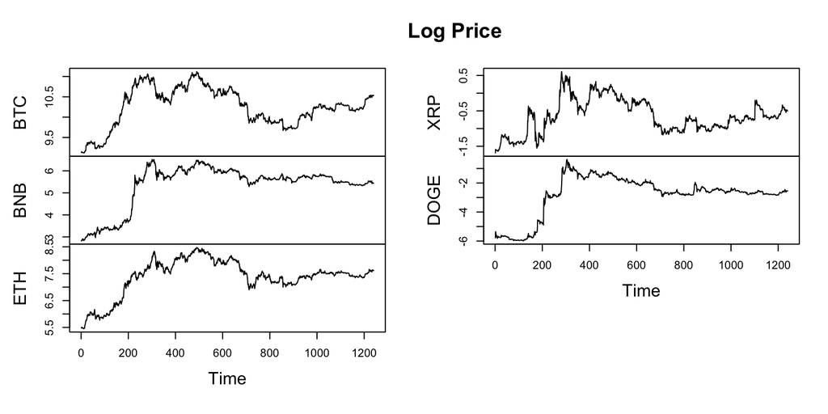

```r
#Convert stock data to Time Series
btc.ts<-ts(data$BTC)
bnb.ts<-ts(data$BNB)
eth.ts<-ts(data$ETH)
xrp.ts<-ts(data$XRP)
doge.ts<-ts(data$DOGE)
#Initialize plot colors
btc.col<-"#FF8C00"
bnb.col<-"#008000"
eth.col<-"#20B2AA"
xrp.col<-"#1E90FF"
doge.col<-"#9932CC"
#Plot each Time Series
plot(ts(data[,2:6]),  main = "Log Price")
```

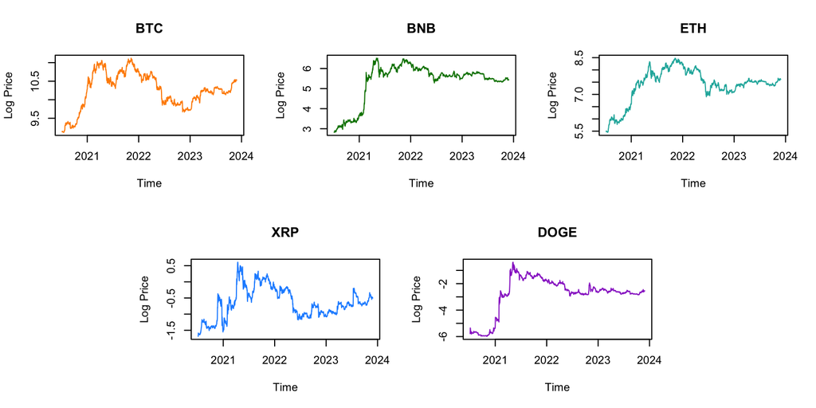

```r
layout(mat = matrix(c(1,1,2,2,3,3,
                      0,4,4,5,5,0), nrow = 2, byrow = TRUE))
plot(data$Date,btc.ts,main="BTC",xlab="Time",ylab="Log Price",col=btc.col,type = "l")
plot(data$Date,bnb.ts,main="BNB",xlab="Time",ylab="Log Price",col=bnb.col,type = "l")
plot(data$Date,eth.ts,main="ETH",xlab="Time",ylab="Log Price",col=eth.col,type = "l")
plot(data$Date,xrp.ts,main="XRP",xlab="Time",ylab="Log Price",col=xrp.col,type = "l")
plot(data$Date,doge.ts,main="DOGE",xlab="Time",ylab="Log Price",col=doge.col,type = "l")
```

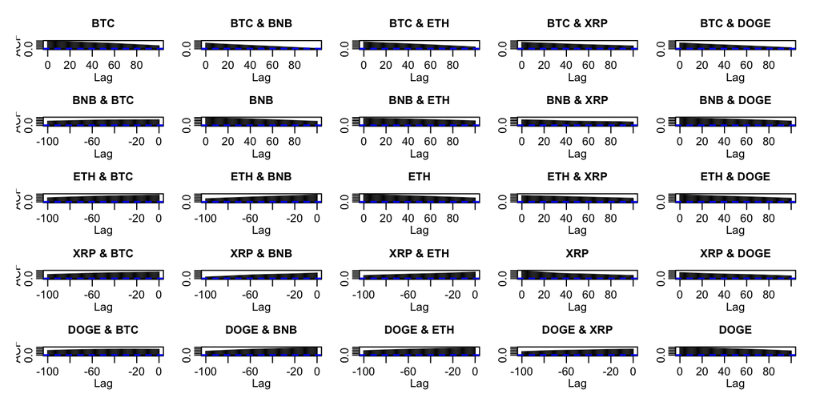

```r
stats::acf(data.train[2:6], lag.max = 100)
```

# Part 2: Multivariate Modeling

Apply the VAR model to the multivariate time series in training data. Use AIC to identify the optimal VAR order. Build an unrestricted VAR model using this order, and print out the selected order and model coefficients. Restrict the VAR model to the statistically significant coefficients and print out the restricted model summary.

```r
stock.var.select<-VARselect(data.train[,2:6],lag.max = 15)
stock.var.select$selection
```

```
## AIC(n)  HQ(n)  SC(n) FPE(n)
##     14      1      1     14
```

```r
stock.var<-VAR(data.train[,2:6],p=1)
stock.var
```

```
##
## VAR Estimation Results:
## =======================
##
## Estimated coefficients for equation BTC:
## ========================================
## Call:
## BTC = BTC.l1 + BNB.l1 + ETH.l1 + XRP.l1 + DOGE.l1 + const
##
##       BTC.l1       BNB.l1       ETH.l1       XRP.l1      DOGE.l1        const
##  1.010453054 -0.005901364 -0.006856781 -0.009388482  0.004536076 -0.017317150
##
##
## Estimated coefficients for equation BNB:
## ========================================
## Call:
## BNB = BTC.l1 + BNB.l1 + ETH.l1 + XRP.l1 + DOGE.l1 + const
##
##      BTC.l1      BNB.l1      ETH.l1      XRP.l1     DOGE.l1       const
##  0.03245643  0.98205874 -0.01853042 -0.02029776  0.01559412 -0.06740983
##
##
## Estimated coefficients for equation ETH:
## ========================================
## Call:
## ETH = BTC.l1 + BNB.l1 + ETH.l1 + XRP.l1 + DOGE.l1 + const
##
##       BTC.l1       BNB.l1       ETH.l1       XRP.l1      DOGE.l1        const
##  0.028209810 -0.004640940  0.970768704 -0.011155288  0.009697286 -0.026947146
##
##
## Estimated coefficients for equation XRP:
## ========================================
## Call:
## XRP = BTC.l1 + BNB.l1 + ETH.l1 + XRP.l1 + DOGE.l1 + const
##
##        BTC.l1        BNB.l1        ETH.l1        XRP.l1       DOGE.l1
##  0.0307936097 -0.0006143485 -0.0171753404  0.9728424022  0.0055975464
##         const
## -0.1866617620
##
##
## Estimated coefficients for equation DOGE:
## =========================================
## Call:
## DOGE = BTC.l1 + BNB.l1 + ETH.l1 + XRP.l1 + DOGE.l1 + const
##
##       BTC.l1       BNB.l1       ETH.l1       XRP.l1      DOGE.l1        const
##  0.031928629  0.011780747 -0.012740892 -0.003175539  0.986826723 -0.332680950
```

** Testing Granger Causality **

```r
#Check covariance matrix column names
var.model = vcov(stock.var)
colnames(var.model)
```

```
##  [1] "BTC:(Intercept)"  "BTC:BTC.l1"       "BTC:BNB.l1"       "BTC:ETH.l1"
##  [5] "BTC:XRP.l1"       "BTC:DOGE.l1"      "BNB:(Intercept)"  "BNB:BTC.l1"
##  [9] "BNB:BNB.l1"       "BNB:ETH.l1"       "BNB:XRP.l1"       "BNB:DOGE.l1"
## [13] "ETH:(Intercept)"  "ETH:BTC.l1"       "ETH:BNB.l1"       "ETH:ETH.l1"
## [17] "ETH:XRP.l1"       "ETH:DOGE.l1"      "XRP:(Intercept)"  "XRP:BTC.l1"
## [21] "XRP:BNB.l1"       "XRP:ETH.l1"       "XRP:XRP.l1"       "XRP:DOGE.l1"
## [25] "DOGE:(Intercept)" "DOGE:BTC.l1"      "DOGE:BNB.l1"      "DOGE:ETH.l1"
## [29] "DOGE:XRP.l1"      "DOGE:DOGE.l1"
```

** BTC **

```r
# Check coefficients for BTC column names
coefs = coefficients(stock.var)$BTC[,1]
names(coefs)
```

```
## [1] "BTC.l1"  "BNB.l1"  "ETH.l1"  "XRP.l1"  "DOGE.l1" "const"
```

```r
# Test Granger causality from BNB to BTC
wald.test(coefs[c(2)], Sigma = var.model[c(3),c(3)], Terms = 1)
```

```
## Wald test:
## ----------
##
## Chi-squared test:
## X2 = 2.3, df = 1, P(> X2) = 0.13
```

```r
# Test Granger causality from ETH to BTC
wald.test(coefs[c(3)], Sigma = var.model[c(4),c(4)], Terms = 1)
```

```
## Wald test:
## ----------
##
## Chi-squared test:
## X2 = 0.93, df = 1, P(> X2) = 0.33
```

```r
# Test Granger causality from XRP to BTC
wald.test(coefs[c(4)], Sigma = var.model[c(5),c(5)], Terms = 1)
```

```
## Wald test:
## ----------
##
## Chi-squared test:
## X2 = 5.7, df = 1, P(> X2) = 0.017
```

```r
# Test Granger causality from DOGE to BTC
wald.test(coefs[c(5)], Sigma = var.model[c(6),c(6)], Terms = 1)
```

```
## Wald test:
## ----------
##
## Chi-squared test:
## X2 = 2.7, df = 1, P(> X2) = 0.1
```

** BNB **

```r
# Check coefficients for BNB column names
coefs = coefficients(stock.var)$BNB[,1]
names(coefs)
```

```
## [1] "BTC.l1"  "BNB.l1"  "ETH.l1"  "XRP.l1"  "DOGE.l1" "const"
```

```r
# Test Granger causality from BTC to BNB
wald.test(coefs[c(1)], Sigma = var.model[c(8),c(8)], Terms = 1)
```

```
## Wald test:
## ----------
##
## Chi-squared test:
## X2 = 15.9, df = 1, P(> X2) = 6.8e-05
```

```r
# Test Granger causality from ETH to BNB
wald.test(coefs[c(3)], Sigma = var.model[c(10),c(10)], Terms = 1)
```

```
## Wald test:
## ----------
##
## Chi-squared test:
## X2 = 3.2, df = 1, P(> X2) = 0.074
```

```r
# Test Granger causality from XRP to BNB
wald.test(coefs[c(4)], Sigma = var.model[c(11),c(11)], Terms = 1)
```

```
## Wald test:
## ----------
##
## Chi-squared test:
## X2 = 12.4, df = 1, P(> X2) = 0.00044
```

```r
# Test Granger causality from DOGE to BTC
wald.test(coefs[c(5)], Sigma = var.model[c(12),c(12)], Terms = 1)
```

```
## Wald test:
## ----------
##
## Chi-squared test:
## X2 = 14.8, df = 1, P(> X2) = 0.00012
```

** ETH **

```r
# Check coefficients for ETH column names
coefs = coefficients(stock.var)$ETH[,1]
names(coefs)
```

```
## [1] "BTC.l1"  "BNB.l1"  "ETH.l1"  "XRP.l1"  "DOGE.l1" "const"
```

```r
# Test Granger causality from BTC to ETH
wald.test(coefs[c(1)], Sigma = var.model[c(14),c(14)], Terms = 1)
```

```
## Wald test:
## ----------
##
## Chi-squared test:
## X2 = 14.6, df = 1, P(> X2) = 0.00013
```

```r
# Test Granger causality from BNB to ETH
wald.test(coefs[c(2)], Sigma = var.model[c(15),c(15)], Terms = 1)
```

```
## Wald test:
## ----------
##
## Chi-squared test:
## X2 = 0.82, df = 1, P(> X2) = 0.37
```

```r
# Test Granger causality from XRP to ETH
wald.test(coefs[c(4)], Sigma = var.model[c(17),c(17)], Terms = 1)
```

```
## Wald test:
## ----------
##
## Chi-squared test:
## X2 = 4.6, df = 1, P(> X2) = 0.033
```

```r
# Test Granger causality from DOGE to BTC
wald.test(coefs[c(5)], Sigma = var.model[c(18),c(18)], Terms = 1)
```

```
## Wald test:
## ----------
##
## Chi-squared test:
## X2 = 7.0, df = 1, P(> X2) = 0.0082
```

** XRP **

```r
# Check coefficients for XRP column names
coefs = coefficients(stock.var)$XRP[,1]
names(coefs)
```

```
## [1] "BTC.l1"  "BNB.l1"  "ETH.l1"  "XRP.l1"  "DOGE.l1" "const"
```

```r
# Test Granger causality from BTC to XRP
wald.test(coefs[c(1)], Sigma = var.model[c(20),c(20)], Terms = 1)
```

```
## Wald test:
## ----------
##
## Chi-squared test:
## X2 = 9.3, df = 1, P(> X2) = 0.0022
```

```r
# Test Granger causality from BNB to XRP
wald.test(coefs[c(2)], Sigma = var.model[c(21),c(21)], Terms = 1)
```

```
## Wald test:
## ----------
##
## Chi-squared test:
## X2 = 0.0077, df = 1, P(> X2) = 0.93
```

```r
# Test Granger causality from ETH to XRP
wald.test(coefs[c(3)], Sigma = var.model[c(22),c(22)], Terms = 1)
```

```
## Wald test:
## ----------
##
## Chi-squared test:
## X2 = 1.8, df = 1, P(> X2) = 0.18
```

```r
# Test Granger causality from DOGE to XRP
wald.test(coefs[c(5)], Sigma = var.model[c(24),c(24)], Terms = 1)
```

```
## Wald test:
## ----------
##
## Chi-squared test:
## X2 = 1.2, df = 1, P(> X2) = 0.26
```

** DOGE **

```r
# Check coefficients for DOGE column names
coefs = coefficients(stock.var)$DOGE[,1]
names(coefs)
```

```
## [1] "BTC.l1"  "BNB.l1"  "ETH.l1"  "XRP.l1"  "DOGE.l1" "const"
```

```r
# Test Granger causality from BTC to DOGE
wald.test(coefs[c(1)], Sigma = var.model[c(26),c(26)], Terms = 1)
```

```
## Wald test:
## ----------
##
## Chi-squared test:
## X2 = 5.3, df = 1, P(> X2) = 0.022
```

```r
# Test Granger causality from BNB to DOGE
wald.test(coefs[c(2)], Sigma = var.model[c(27),c(27)], Terms = 1)
```

```
## Wald test:
## ----------
##
## Chi-squared test:
## X2 = 1.5, df = 1, P(> X2) = 0.22
```

```r
# Test Granger causality from ETH to DOGE
wald.test(coefs[c(3)], Sigma = var.model[c(28),c(28)], Terms = 1)
```

```
## Wald test:
## ----------
##
## Chi-squared test:
## X2 = 0.52, df = 1, P(> X2) = 0.47
```

```r
# Test Granger causality from XRP to DOGE
wald.test(coefs[c(4)], Sigma = var.model[c(29),c(29)], Terms = 1)
```

```
## Wald test:
## ----------
##
## Chi-squared test:
## X2 = 0.1, df = 1, P(> X2) = 0.75
```

```r
stock.var.restricted <- restrict(stock.var)
summary(stock.var.restricted)
```

```
##
## VAR Estimation Results:
## =========================
## Endogenous variables: BTC, BNB, ETH, XRP, DOGE
## Deterministic variables: const
## Sample size: 1225
## Log Likelihood: 11034.301
## Roots of the characteristic polynomial:
## 0.9974 0.9974 0.9731 0.9731 0.9681
## Call:
## VAR(y = data.train[, 2:6], p = 1)
##
##
## Estimation results for equation BTC:
## ====================================
## BTC = BTC.l1 + BNB.l1
##
##          Estimate Std. Error  t value Pr(>|t|)
## BTC.l1  1.0023958  0.0006174 1623.700  < 2e-16 ***
## BNB.l1 -0.0043931  0.0011664   -3.766 0.000174 ***
## ---
## Signif. codes:  0 '***' 0.001 '**' 0.01 '*' 0.05 '.' 0.1 ' ' 1
##
##
## Residual standard error: 0.03321 on 1223 degrees of freedom
## Multiple R-Squared:     1,   Adjusted R-squared:     1
## F-statistic: 5.851e+07 on 2 and 1223 DF,  p-value: < 2.2e-16
##
##
## Estimation results for equation BNB:
## ====================================
## BNB = BTC.l1 + BNB.l1 + XRP.l1 + DOGE.l1
##
##          Estimate Std. Error t value Pr(>|t|)
## BTC.l1   0.016457   0.002989   5.506 4.48e-08 ***
## BNB.l1   0.974850   0.004501 216.586  < 2e-16 ***
## XRP.l1  -0.018155   0.005110  -3.553 0.000396 ***
## DOGE.l1  0.015683   0.003246   4.831 1.53e-06 ***
## ---
## Signif. codes:  0 '***' 0.001 '**' 0.01 '*' 0.05 '.' 0.1 ' ' 1
```

[output cut: 59 more lines]

```
## Covariance matrix of residuals:
##           BTC      BNB      ETH      XRP     DOGE
## BTC  0.001107 0.001053 0.001182 0.001104 0.001233
## BNB  0.001053 0.002362 0.001451 0.001534 0.001316
## ETH  0.001182 0.001451 0.001934 0.001560 0.001569
## XRP  0.001104 0.001534 0.001560 0.003605 0.001691
## DOGE 0.001233 0.001316 0.001569 0.001691 0.006865
##
## Correlation matrix of residuals:
##         BTC    BNB    ETH    XRP   DOGE
## BTC  1.0000 0.6516 0.8080 0.5529 0.4475
## BNB  0.6516 1.0000 0.6787 0.5256 0.3268
## ETH  0.8080 0.6787 1.0000 0.5906 0.4307
## XRP  0.5529 0.5256 0.5906 1.0000 0.3399
## DOGE 0.4475 0.3268 0.4307 0.3399 1.0000
```

```r
BIC(stock.var)
```

```
## [1] -21885.76
```

```r
BIC(stock.var.restricted)
```

```
## [1] -21961.94
```

** Residual analysis for VAR **

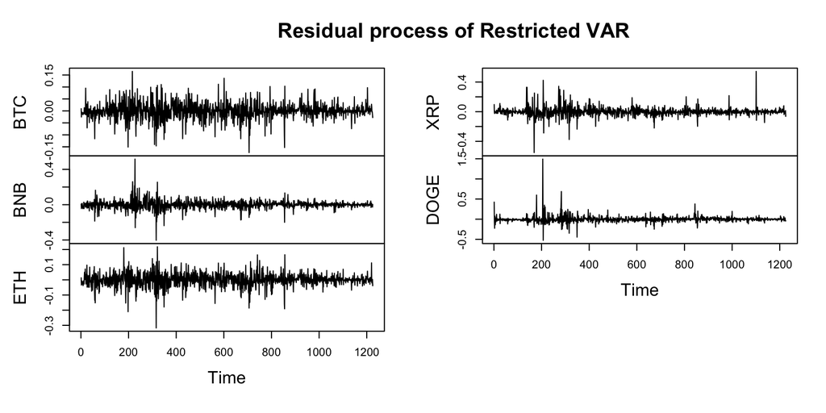

```r
plot(ts(residuals(stock.var.restricted)), main = "Residual process of Restricted VAR")
```

```r
vars::arch.test(stock.var.restricted)
```

```
##
##  ARCH (multivariate)
##
## data:  Residuals of VAR object stock.var.restricted
## Chi-squared = 6046.3, df = 1125, p-value < 2.2e-16
```

```r
normality.test(stock.var.restricted)
```

```
## $JB
##
##  JB-Test (multivariate)
##
## data:  Residuals of VAR object stock.var.restricted
## Chi-squared = 976384, df = 10, p-value < 2.2e-16
##
##
## $Skewness
##
##  Skewness only (multivariate)
##
## data:  Residuals of VAR object stock.var.restricted
## Chi-squared = 12549, df = 5, p-value < 2.2e-16
##
##
## $Kurtosis
##
##  Kurtosis only (multivariate)
##
## data:  Residuals of VAR object stock.var.restricted
## Chi-squared = 963835, df = 5, p-value < 2.2e-16
```

```r
serial.test(stock.var.restricted)
```

```
##
##  Portmanteau Test (asymptotic)
##
## data:  Residuals of VAR object stock.var.restricted
## Chi-squared = 1117.9, df = 375, p-value < 2.2e-16
```

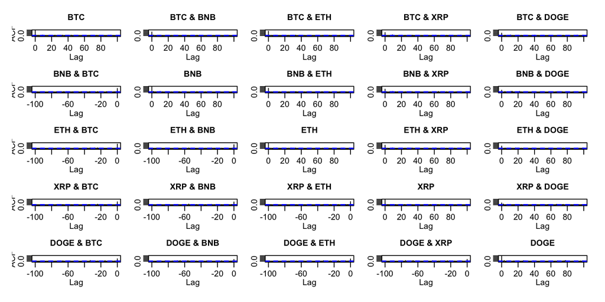

```r
stats::acf(ts(residuals(stock.var.restricted)), lag.max = 100)
```

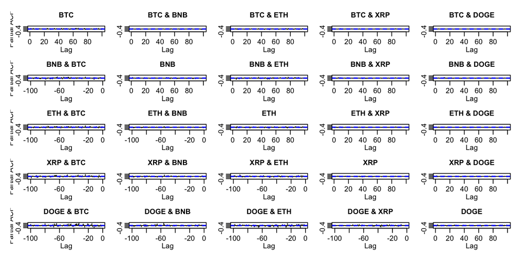

```r
stats::pacf(ts(residuals(stock.var.restricted)), lag.max = 100)
```

We can see that the arch effect is present, therefore there’s some heteroskedasticity. The results of the normality test show that the residuals aren’t normally distributed. From the serial test follows that there is some serial correlation.

** Rolling predictions **

We use 1-step-ahead rolling prediction on the restricted VAR model. We compare the predictions with the previous models using MAE and Precision Measure for each time series.

```r
resmat <- stock.var.restricted$restrictions
nfore <- length(data.test[,1])
l <- length(btc.ts)
btc.var.pred <- NULL
bnb.var.pred <- NULL
eth.var.pred <- NULL
xrp.var.pred <- NULL
doge.var.pred <- NULL
for(f in 1: nfore){
    ## Fit models
    data = data.train[,2:6]
    if(f>=2){
       data = rbind(data.train[,2:6],data.test[1:(f-1),2:6])
    }
    final.model.1 = VAR(data, p=1)
    final.model.2 = restrict(final.model.1, method = 'manual', resmat = resmat)
    ## Forecast
    btc.var.pred = rbind(btc.var.pred,predict(final.model.2, n.ahead=1,ci = 0.95)$fcst$BTC[,1:3])
    bnb.var.pred = rbind(bnb.var.pred,predict(final.model.2, n.ahead=1,ci = 0.95)$fcst$BNB[,1:3])
    eth.var.pred = rbind(eth.var.pred,predict(final.model.2, n.ahead=1,ci = 0.95)$fcst$ETH[,1:3])
    xrp.var.pred = rbind(xrp.var.pred,predict(final.model.2, n.ahead=1,ci = 0.95)$fcst$XRP[,1:3])
    doge.var.pred = rbind(doge.var.pred,predict(final.model.2, n.ahead=1,ci = 0.95)$fcst$DOGE[,1:3])
}
colnames(btc.var.pred) <- c("fcst","lower","upper")
colnames(bnb.var.pred) <- c("fcst","lower","upper")
colnames(eth.var.pred) <- c("fcst","lower","upper")
colnames(xrp.var.pred) <- c("fcst","lower","upper")
colnames(doge.var.pred) <- c("fcst","lower","upper")
```

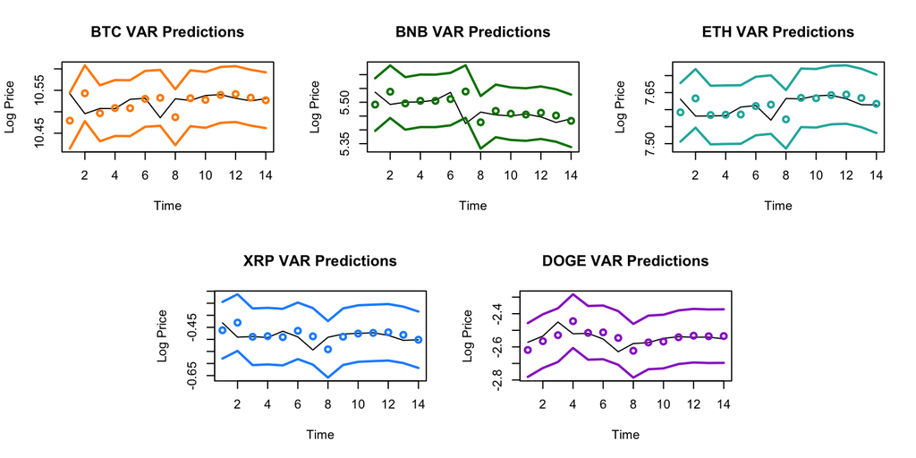

```r
layout(mat = matrix(c(1,1,2,2,3,3,
                      0,4,4,5,5,0), nrow = 2, byrow = TRUE))
plot(btc.ts[(l-13):l],type="l",ylab="Log Price",xlab="Time",main="BTC VAR Predictions",
     ylim = c(min(btc.var.pred[,2]),max(btc.var.pred[,3])))
points(ts(btc.var.pred[,1],start=1),lwd=2,col=btc.col)
lines(ts(btc.var.pred[,2],start=1),lwd=2,col=btc.col)
lines(ts(btc.var.pred[,3],start=1),lwd=2,col=btc.col)
plot(bnb.ts[(l-13):l],type="l",ylab="Log Price",xlab="Time",main="BNB VAR Predictions",
     ylim = c(min(bnb.var.pred[,2]),max(bnb.var.pred[,3])))
points(ts(bnb.var.pred[,1],start=1),lwd=2,col=bnb.col)
lines(ts(bnb.var.pred[,2],start=1),lwd=2,col=bnb.col)
lines(ts(bnb.var.pred[,3],start=1),lwd=2,col=bnb.col)
plot(eth.ts[(l-13):l],type="l",ylab="Log Price",xlab="Time",main="ETH VAR Predictions",
     ylim = c(min(eth.var.pred[,2]),max(eth.var.pred[,3])))
points(ts(eth.var.pred[,1],start=1),lwd=2,col=eth.col)
lines(ts(eth.var.pred[,2],start=1),lwd=2,col=eth.col)
lines(ts(eth.var.pred[,3],start=1),lwd=2,col=eth.col)
plot(xrp.ts[(l-13):l],type="l",ylab="Log Price",xlab="Time",main="XRP VAR Predictions",
     ylim = c(min(xrp.var.pred[,2]),max(xrp.var.pred[,3])))
points(ts(xrp.var.pred[,1],start=1),lwd=2,col=xrp.col)
lines(ts(xrp.var.pred[,2],start=1),lwd=2,col=xrp.col)
lines(ts(xrp.var.pred[,3],start=1),lwd=2,col=xrp.col)
plot(doge.ts[(l-13):l],type="l",ylab="Log Price",xlab="Time",main="DOGE VAR Predictions",
     ylim = c(min(doge.var.pred[,2]),max(doge.var.pred[,3])))
points(ts(doge.var.pred[,1],start=1),lwd=2,col=doge.col)
lines(ts(doge.var.pred[,2],start=1),lwd=2,col=doge.col)
lines(ts(doge.var.pred[,3],start=1),lwd=2,col=doge.col)
```

```r
cat("BTC VAR MAE:",mean(abs(btc.var.pred[,1]-data.test[,2])),"\nBTC VAR PM:",
sum((btc.var.pred[,1]-data.test[,2])^2)/sum((data.test[,2]-mean(data.test[,2]))^2))
```

```
## BTC VAR MAE: 0.01934953
## BTC VAR PM: 2.921674
```

```r
cat("BNB VAR MAE:",mean(abs(bnb.var.pred[,1]-data.test[,3])),"\nBNB VAR PM:",
sum((bnb.var.pred[,1]-data.test[,3])^2)/sum((data.test[,3]-mean(data.test[,3]))^2))
```

```
## BNB VAR MAE: 0.02510403
## BNB VAR PM: 1.116127
```

```r
cat("ETH VAR MAE:",mean(abs(eth.var.pred[,1]-data.test[,4])),"\nBTC VAR PM:",
sum((eth.var.pred[,1]-data.test[,4])^2)/sum((data.test[,4]-mean(data.test[,4]))^2))
```

```
## ETH VAR MAE: 0.01944126
## BTC VAR PM: 1.399278
```

```r
cat("XRP VAR MAE:",mean(abs(xrp.var.pred[,1]-data.test[,5])),"\nXRP VAR PM:",
sum((xrp.var.pred[,1]-data.test[,5])^2)/sum((data.test[,5]-mean(data.test[,5]))^2))
```

```
## XRP VAR MAE: 0.02162154
## XRP VAR PM: 1.585605
```

```r
cat("DOGE VAR MAE:",mean(abs(doge.var.pred[,1]-data.test[,6])),"\nDOGE VAR PM:",
sum((doge.var.pred[,1]-data.test[,6])^2)/sum((data.test[,6]-mean(data.test[,6]))^2))
```

```
## DOGE VAR MAE: 0.03275583
## DOGE VAR PM: 1.28989
```

** N - ahead predictions **

```r
nfore <- length(data.test[,1])
l <- length(btc.ts)
fore.var.restrict = predict(stock.var.restricted,n.ahead=14,ci=0.95)
btc.var.pred = fore.var.restrict$fcst$BTC[,1:3]
bnb.var.pred = fore.var.restrict$fcst$BNB[,1:3]
eth.var.pred = fore.var.restrict$fcst$ETH[,1:3]
xrp.var.pred = fore.var.restrict$fcst$XRP[,1:3]
doge.var.pred = fore.var.restrict$fcst$DOGE[,1:3]
colnames(btc.var.pred) <- c("fcst","lower","upper")
colnames(bnb.var.pred) <- c("fcst","lower","upper")
colnames(eth.var.pred) <- c("fcst","lower","upper")
colnames(xrp.var.pred) <- c("fcst","lower","upper")
colnames(doge.var.pred) <- c("fcst","lower","upper")
```

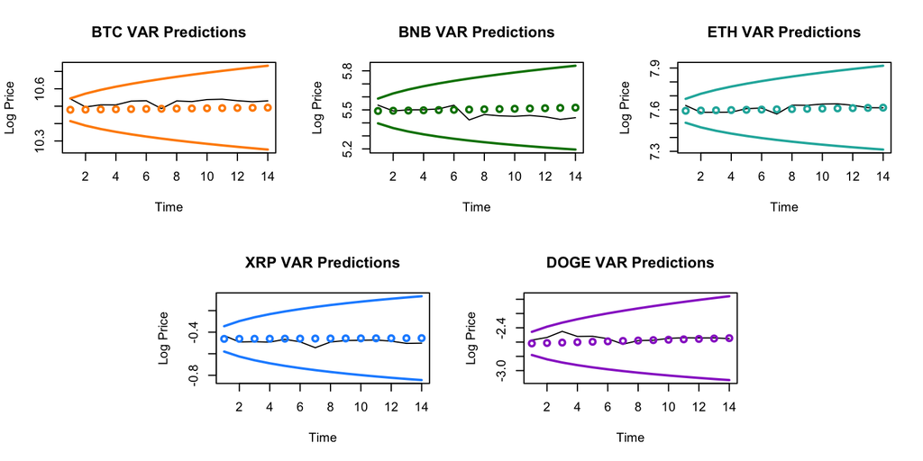

```r
layout(mat = matrix(c(1,1,2,2,3,3,
                      0,4,4,5,5,0), nrow = 2, byrow = TRUE))
plot(btc.ts[(l-13):l],type="l",ylab="Log Price",xlab="Time",main="BTC VAR Predictions",
     ylim = c(min(btc.var.pred[,2]),max(btc.var.pred[,3])))
points(ts(btc.var.pred[,1],start=1),lwd=2,col=btc.col)
lines(ts(btc.var.pred[,2],start=1),lwd=2,col=btc.col)
lines(ts(btc.var.pred[,3],start=1),lwd=2,col=btc.col)
plot(bnb.ts[(l-13):l],type="l",ylab="Log Price",xlab="Time",main="BNB VAR Predictions",
     ylim = c(min(bnb.var.pred[,2]),max(bnb.var.pred[,3])))
points(ts(bnb.var.pred[,1],start=1),lwd=2,col=bnb.col)
lines(ts(bnb.var.pred[,2],start=1),lwd=2,col=bnb.col)
lines(ts(bnb.var.pred[,3],start=1),lwd=2,col=bnb.col)
plot(eth.ts[(l-13):l],type="l",ylab="Log Price",xlab="Time",main="ETH VAR Predictions",
     ylim = c(min(eth.var.pred[,2]),max(eth.var.pred[,3])))
points(ts(eth.var.pred[,1],start=1),lwd=2,col=eth.col)
lines(ts(eth.var.pred[,2],start=1),lwd=2,col=eth.col)
lines(ts(eth.var.pred[,3],start=1),lwd=2,col=eth.col)
plot(xrp.ts[(l-13):l],type="l",ylab="Log Price",xlab="Time",main="XRP VAR Predictions",
     ylim = c(min(xrp.var.pred[,2]),max(xrp.var.pred[,3])))
points(ts(xrp.var.pred[,1],start=1),lwd=2,col=xrp.col)
lines(ts(xrp.var.pred[,2],start=1),lwd=2,col=xrp.col)
lines(ts(xrp.var.pred[,3],start=1),lwd=2,col=xrp.col)
plot(doge.ts[(l-13):l],type="l",ylab="Log Price",xlab="Time",main="DOGE VAR Predictions",
     ylim = c(min(doge.var.pred[,2]),max(doge.var.pred[,3])))
points(ts(doge.var.pred[,1],start=1),lwd=2,col=doge.col)
lines(ts(doge.var.pred[,2],start=1),lwd=2,col=doge.col)
lines(ts(doge.var.pred[,3],start=1),lwd=2,col=doge.col)
```

```r
cat("BTC VAR MAE:",mean(abs(btc.var.pred[,1]-data.test[,2])),"\nBTC VAR PM:",
sum((btc.var.pred[,1]-data.test[,2])^2)/sum((data.test[,2]-mean(data.test[,2]))^2))
```

```
## BTC VAR MAE: 0.03742316
## BTC VAR PM: 6.063455
```

```r
cat("BNB VAR MAE:",mean(abs(bnb.var.pred[,1]-data.test[,3])),"\nBNB VAR PM:",
sum((bnb.var.pred[,1]-data.test[,3])^2)/sum((data.test[,3]-mean(data.test[,3]))^2))
```

```
## BNB VAR MAE: 0.04389158
## BNB VAR PM: 2.055446
```

```r
cat("ETH VAR MAE:",mean(abs(eth.var.pred[,1]-data.test[,4])),"\nBTC VAR PM:",
sum((eth.var.pred[,1]-data.test[,4])^2)/sum((data.test[,4]-mean(data.test[,4]))^2))
```

```
## ETH VAR MAE: 0.01971228
## BTC VAR PM: 0.9341192
```

```r
cat("XRP VAR MAE:",mean(abs(xrp.var.pred[,1]-data.test[,5])),"\nXRP VAR PM:",
sum((xrp.var.pred[,1]-data.test[,5])^2)/sum((data.test[,5]-mean(data.test[,5]))^2))
```

```
## XRP VAR MAE: 0.03189818
## XRP VAR PM: 2.420154
```

```r
cat("DOGE VAR MAE:",mean(abs(doge.var.pred[,1]-data.test[,6])),"\nDOGE VAR PM:",
sum((doge.var.pred[,1]-data.test[,6])^2)/sum((data.test[,6]-mean(data.test[,6]))^2))
```

```
## DOGE VAR MAE: 0.04261002
## DOGE VAR PM: 2.437002
```

*Response:* The observed values almost all fall into the prediction interval.

*** Optimal VAR according to AIC ***

The optimal VAR order to model the five stock price time series using AIC as the selection criteria is 14. The summary of this model is shown below:

```r
stock.var<-VAR(data.train[,2:6],p=14)
stock.var
```

```
##
## VAR Estimation Results:
## =======================
##
## Estimated coefficients for equation BTC:
## ========================================
## Call:
## BTC = BTC.l1 + BNB.l1 + ETH.l1 + XRP.l1 + DOGE.l1 + BTC.l2 + BNB.l2 + ETH.l2 + XRP.l2 + DOGE.l2 + BTC.l3 + BNB.l3 + ETH.l3 + XRP.l3 + DOGE.l3 + BTC.l4 + BNB.l4 + ETH.l4 + XRP.l4 + DOGE.l4 + BTC.l5 + BNB.l5 + ETH.l5 + XRP.l5 + DOGE.l5 + BTC.l6 + BNB.l6 + ETH.l6 + XRP.l6 + DOGE.l6 + BTC.l7 + BNB.l7…
##
##       BTC.l1       BNB.l1       ETH.l1       XRP.l1      DOGE.l1       BTC.l2
##  1.109506946 -0.059336416 -0.029848799 -0.037043430  0.008183378 -0.167882125
##       BNB.l2       ETH.l2       XRP.l2      DOGE.l2       BTC.l3       BNB.l3
##  0.127264794  0.059926364 -0.009797683 -0.004754701  0.154229231 -0.072887645
##       ETH.l3       XRP.l3      DOGE.l3       BTC.l4       BNB.l4       ETH.l4
## -0.030695965  0.026671120 -0.036599248 -0.128986961 -0.006844856  0.043570465
##       XRP.l4      DOGE.l4       BTC.l5       BNB.l5       ETH.l5       XRP.l5
## -0.003101678  0.065466132  0.130213129 -0.018572881 -0.083094735 -0.008570058
##      DOGE.l5       BTC.l6       BNB.l6       ETH.l6       XRP.l6      DOGE.l6
## -0.009730918 -0.127373707  0.001472434  0.080369220  0.045466448 -0.024969029
##       BTC.l7       BNB.l7       ETH.l7       XRP.l7      DOGE.l7       BTC.l8
##  0.046742852  0.055415964 -0.153242380  0.016988560  0.012210993  0.005102862
##       BNB.l8       ETH.l8       XRP.l8      DOGE.l8       BTC.l9       BNB.l9
## -0.007124108  0.042103700 -0.030834195 -0.029528877  0.066101587 -0.065326170
##       ETH.l9       XRP.l9      DOGE.l9      BTC.l10      BNB.l10      ETH.l10
##  0.020150337  0.065688905  0.030017038 -0.166188018  0.098378376  0.093166585
##      XRP.l10     DOGE.l10      BTC.l11      BNB.l11      ETH.l11      XRP.l11
## -0.094212744 -0.028993690  0.160535384 -0.075325196 -0.105699295 -0.018862170
##     DOGE.l11      BTC.l12      BNB.l12      ETH.l12      XRP.l12     DOGE.l12
##  0.067248197 -0.096340488  0.020343366  0.068710821  0.010268872 -0.024650337
##      BTC.l13      BNB.l13      ETH.l13      XRP.l13     DOGE.l13      BTC.l14
##  0.101620431 -0.071810716 -0.023685337  0.015107528  0.007232812 -0.078446519
##      BNB.l14      ETH.l14      XRP.l14     DOGE.l14        const
##  0.070714336  0.009223933  0.016745803 -0.027800718  0.002625069
##
##
## Estimated coefficients for equation BNB:
## ========================================
## Call:
## BNB = BTC.l1 + BNB.l1 + ETH.l1 + XRP.l1 + DOGE.l1 + BTC.l2 + BNB.l2 + ETH.l2 + XRP.l2 + DOGE.l2 + BTC.l3 + BNB.l3 + ETH.l3 + XRP.l3 + DOGE.l3 + BTC.l4 + BNB.l4 + ETH.l4 + XRP.l4 + DOGE.l4 + BTC.l5 + BNB.l5 + ETH.l5 + XRP.l5 + DOGE.l5 + BTC.l6 + BNB.l6 + ETH.l6 + XRP.l6 + DOGE.l6 + BTC.l7 + BNB.l7…
##
```

[output cut: 114 more lines]

```
## -0.1928910821 -0.2162676772  0.2681113842  0.1654642975 -0.1229670160
##        BTC.l9        BNB.l9        ETH.l9        XRP.l9       DOGE.l9
##  0.0379489451 -0.1891706761  0.3849962075 -0.1701136520  0.1277883631
##       BTC.l10       BNB.l10       ETH.l10       XRP.l10      DOGE.l10
## -0.1059290801  0.2257708994 -0.0613672724 -0.1318203582 -0.0579548321
##       BTC.l11       BNB.l11       ETH.l11       XRP.l11      DOGE.l11
##  0.2997405098 -0.0284385146 -0.2752166739  0.1196471628 -0.0047451753
##       BTC.l12       BNB.l12       ETH.l12       XRP.l12      DOGE.l12
## -0.5316514451  0.1123073134  0.3370589536 -0.2216052625  0.0886375769
##       BTC.l13       BNB.l13       ETH.l13       XRP.l13      DOGE.l13
##  0.4123602475 -0.2043275250 -0.1891622520  0.1861259318 -0.0460110795
##       BTC.l14       BNB.l14       ETH.l14       XRP.l14      DOGE.l14
##  0.0479439630  0.0972122099 -0.0643243539 -0.0079648404 -0.0242211948
##         const
## -0.4108713886
```

```r
stock.var.restricted <- restrict(stock.var)
summary(stock.var.restricted)
```

```
##
## VAR Estimation Results:
## =========================
## Endogenous variables: BTC, BNB, ETH, XRP, DOGE
## Deterministic variables: const
## Sample size: 1212
## Log Likelihood: 11219.798
## Roots of the characteristic polynomial:
## 0.9972 0.9972 0.9788 0.9784 0.9784 0.9276 0.9276 0.9135 0.9135 0.8787 0.8787 0.8743 0.8743 0.8641 0.8641 0.8626 0.8626 0.8614 0.8614 0.8606 0.8606 0.8594 0.8594 0.8565 0.856 0.856 0.8524 0.8524 0.8515 0.8515 0.8491 0.8491 0.8466 0.8466 0.8443 0.8443 0.8438 0.8438 0.8416 0.8416 0.8389 0.8389 0.838…
## Call:
## VAR(y = data.train[, 2:6], p = 14)
##
##
## Estimation results for equation BTC:
## ====================================
## BTC = BTC.l1 + BNB.l1 + XRP.l1 + BTC.l2 + BNB.l2 + BTC.l3 + BNB.l3 + DOGE.l3 + BTC.l4 + DOGE.l4 + XRP.l6 + DOGE.l6 + ETH.l7 + XRP.l9 + BNB.l10 + ETH.l10 + XRP.l10 + BNB.l11 + DOGE.l11 + XRP.l14 + DOGE.l14
##
##           Estimate Std. Error t value Pr(>|t|)
## BTC.l1    1.079161   0.037258  28.965  < 2e-16 ***
## BNB.l1   -0.077942   0.025498  -3.057 0.002287 **
## XRP.l1   -0.030997   0.008398  -3.691 0.000234 ***
## BTC.l2   -0.125516   0.052917  -2.372 0.017852 *
## BNB.l2    0.153690   0.035228   4.363 1.40e-05 ***
## BTC.l3    0.141863   0.049438   2.870 0.004183 **
## BNB.l3   -0.083181   0.026774  -3.107 0.001936 **
## DOGE.l3  -0.036032   0.012893  -2.795 0.005278 **
## BTC.l4   -0.086048   0.032373  -2.658 0.007965 **
## DOGE.l4   0.067906   0.014717   4.614 4.38e-06 ***
## XRP.l6    0.042937   0.013513   3.178 0.001523 **
## DOGE.l6  -0.036391   0.010125  -3.594 0.000339 ***
## ETH.l7   -0.054495   0.015601  -3.493 0.000495 ***
## XRP.l9    0.076885   0.017949   4.283 1.99e-05 ***
## BNB.l10   0.057659   0.021464   2.686 0.007325 **
## ETH.l10   0.045097   0.015575   2.896 0.003854 **
## XRP.l10  -0.130411   0.018886  -6.905 8.14e-12 ***
## BNB.l11  -0.054108   0.019600  -2.761 0.005857 **
## DOGE.l11  0.036725   0.009134   4.021 6.17e-05 ***
## XRP.l14   0.035559   0.009297   3.825 0.000138 ***
## DOGE.l14 -0.028780   0.007480  -3.848 0.000126 ***
## ---
```

[output cut: 164 more lines]

```
## Covariance matrix of residuals:
##            BTC       BNB      ETH      XRP     DOGE
## BTC  0.0010734 0.0009649 0.001134 0.001085 0.001220
## BNB  0.0009649 0.0021024 0.001360 0.001478 0.001233
## ETH  0.0011336 0.0013601 0.001916 0.001538 0.001570
## XRP  0.0010845 0.0014778 0.001538 0.003484 0.001659
## DOGE 0.0012201 0.0012328 0.001570 0.001659 0.006451
##
## Correlation matrix of residuals:
##         BTC    BNB    ETH    XRP   DOGE
## BTC  1.0000 0.6423 0.7904 0.5608 0.4637
## BNB  0.6423 1.0000 0.6777 0.5461 0.3348
## ETH  0.7904 0.6777 1.0000 0.5954 0.4467
## XRP  0.5608 0.5461 0.5954 1.0000 0.3500
## DOGE 0.4637 0.3348 0.4467 0.3500 1.0000
```

```r
BIC(stock.var)
```

```
## [1] -20301.05
```

```r
BIC(stock.var.restricted)
```

```
## [1] -21587.59
```

```r
nfore <- length(data.test[,1])
l <- length(btc.ts)
fore.var.restrict = predict(stock.var.restricted,n.ahead=14,ci=0.95)
btc.var.pred = fore.var.restrict$fcst$BTC[,1:3]
bnb.var.pred = fore.var.restrict$fcst$BNB[,1:3]
eth.var.pred = fore.var.restrict$fcst$ETH[,1:3]
xrp.var.pred = fore.var.restrict$fcst$XRP[,1:3]
doge.var.pred = fore.var.restrict$fcst$DOGE[,1:3]
colnames(btc.var.pred) <- c("fcst","lower","upper")
colnames(bnb.var.pred) <- c("fcst","lower","upper")
colnames(eth.var.pred) <- c("fcst","lower","upper")
colnames(xrp.var.pred) <- c("fcst","lower","upper")
colnames(doge.var.pred) <- c("fcst","lower","upper")
```

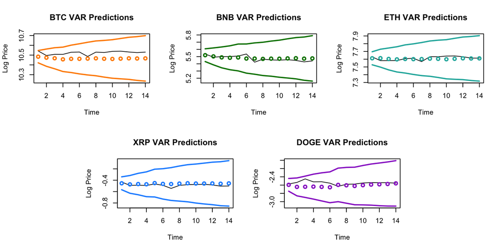

```r
layout(mat = matrix(c(1,1,2,2,3,3,
                      0,4,4,5,5,0), nrow = 2, byrow = TRUE))
plot(btc.ts[(l-13):l],type="l",ylab="Log Price",xlab="Time",main="BTC VAR Predictions",
     ylim = c(min(btc.var.pred[,2]),max(btc.var.pred[,3])))
points(ts(btc.var.pred[,1],start=1),lwd=2,col=btc.col)
lines(ts(btc.var.pred[,2],start=1),lwd=2,col=btc.col)
lines(ts(btc.var.pred[,3],start=1),lwd=2,col=btc.col)
plot(bnb.ts[(l-13):l],type="l",ylab="Log Price",xlab="Time",main="BNB VAR Predictions",
     ylim = c(min(bnb.var.pred[,2]),max(bnb.var.pred[,3])))
points(ts(bnb.var.pred[,1],start=1),lwd=2,col=bnb.col)
lines(ts(bnb.var.pred[,2],start=1),lwd=2,col=bnb.col)
lines(ts(bnb.var.pred[,3],start=1),lwd=2,col=bnb.col)
plot(eth.ts[(l-13):l],type="l",ylab="Log Price",xlab="Time",main="ETH VAR Predictions",
     ylim = c(min(eth.var.pred[,2]),max(eth.var.pred[,3])))
points(ts(eth.var.pred[,1],start=1),lwd=2,col=eth.col)
lines(ts(eth.var.pred[,2],start=1),lwd=2,col=eth.col)
lines(ts(eth.var.pred[,3],start=1),lwd=2,col=eth.col)
plot(xrp.ts[(l-13):l],type="l",ylab="Log Price",xlab="Time",main="XRP VAR Predictions",
     ylim = c(min(xrp.var.pred[,2]),max(xrp.var.pred[,3])))
points(ts(xrp.var.pred[,1],start=1),lwd=2,col=xrp.col)
lines(ts(xrp.var.pred[,2],start=1),lwd=2,col=xrp.col)
lines(ts(xrp.var.pred[,3],start=1),lwd=2,col=xrp.col)
plot(doge.ts[(l-13):l],type="l",ylab="Log Price",xlab="Time",main="DOGE VAR Predictions",
     ylim = c(min(doge.var.pred[,2]),max(doge.var.pred[,3])))
points(ts(doge.var.pred[,1],start=1),lwd=2,col=doge.col)
lines(ts(doge.var.pred[,2],start=1),lwd=2,col=doge.col)
lines(ts(doge.var.pred[,3],start=1),lwd=2,col=doge.col)
```

```r
cat("BTC VAR MAE:",mean(abs(btc.var.pred[,1]-data.test[,2])),"\nBTC VAR PM:",
sum((btc.var.pred[,1]-data.test[,2])^2)/sum((data.test[,2]-mean(data.test[,2]))^2))
```

```
## BTC VAR MAE: 0.05719001
## BTC VAR PM: 13.17338
```

```r
cat("BNB VAR MAE:",mean(abs(bnb.var.pred[,1]-data.test[,3])),"\nBNB VAR PM:",
sum((bnb.var.pred[,1]-data.test[,3])^2)/sum((data.test[,3]-mean(data.test[,3]))^2))
```

```
## BNB VAR MAE: 0.02563298
## BNB VAR PM: 0.6936319
```

```r
cat("ETH VAR MAE:",mean(abs(eth.var.pred[,1]-data.test[,4])),"\nBTC VAR PM:",
sum((eth.var.pred[,1]-data.test[,4])^2)/sum((data.test[,4]-mean(data.test[,4]))^2))
```

```
## ETH VAR MAE: 0.0211853
## BTC VAR PM: 1.037058
```

```r
cat("XRP VAR MAE:",mean(abs(xrp.var.pred[,1]-data.test[,5])),"\nXRP VAR PM:",
sum((xrp.var.pred[,1]-data.test[,5])^2)/sum((data.test[,5]-mean(data.test[,5]))^2))
```

```
## XRP VAR MAE: 0.02871773
## XRP VAR PM: 1.949633
```

```r
cat("DOGE VAR MAE:",mean(abs(doge.var.pred[,1]-data.test[,6])),"\nDOGE VAR PM:",
sum((doge.var.pred[,1]-data.test[,6])^2)/sum((data.test[,6]-mean(data.test[,6]))^2))
```

```
## DOGE VAR MAE: 0.06752606
## DOGE VAR PM: 4.831438
```